# Saratoga

### Report: Pricing Model Comparison

We have two models for predicting the prices of houses in Saratoga. One is the linear regression model and the other one in KNN model. Both these models have their strengths and weaknesses. The main metric for comparing these two models is to check their out of sample prediction error or RMSE. By running the model on more than 500 different train/ test samples we find out that Linear regression model has lower RMSE which means that on average linear model is predicting prices accurately as compared to KNN model.

### Single Random Train/Test Performance

We run both these models on a same train set and predict values for both these models on same test to compare their RMSE and Fit for same data points.

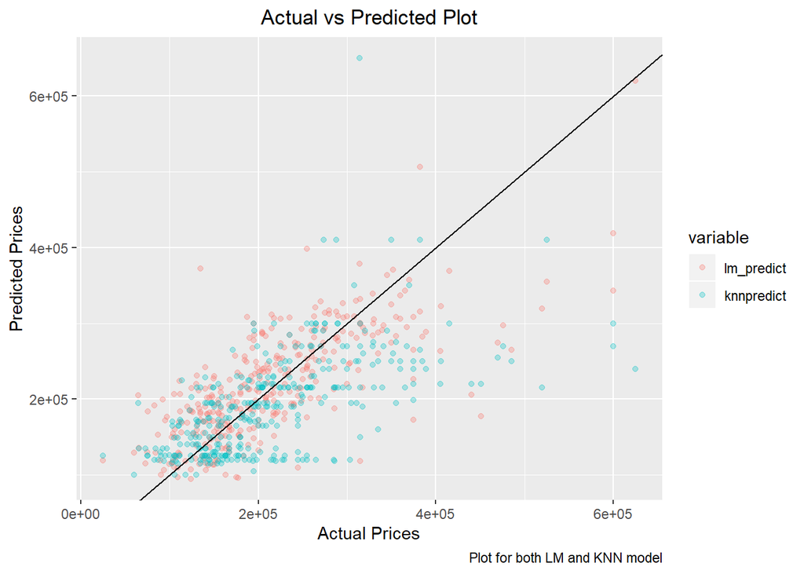

```
## [1] "LM RMSE"
```

```
## [1] 63574.17
```

```
## [1] "KNN RMSE"
```

```
## [1] 77759.13
```

Looking at the actual vs predicted plot we see that KNN model’s predictions are more spread out than LM’s model predictions. We can see that LM model’s prediction are evenly distributed around the center line whereas the KNN model’s predictions tend to be on the lower side of the line thus indicating on average lower prediction of prices as compared to the actual one.Here we see that LM model has better predictions with lower RMSE.

We can also see that the predictions for higher prices are far from the actual prices for both models. This means that both models are not performing good at extreme values. We check the performance of both models on prices in lower and higher percentiles and check how their RMSE perform at the fringe.

We run 100 train/ test random splits of the sample and run both models for every train/test case and then check for RMSE of both models at different percentile of prices. The table below shows that the KNN model has higher error for higher percentile data. That means houses with higher prices are predicted more inaccurately as compared to houses with average prices. The RMSE of LM model is also high but lower than KNN model but for lower percentiles, LM model has slightly higher RMSE than KNN, however the difference is not as stark as for higher percentile values. Here we can also prefer LM model over KNN as it also performs better at extreme values.

Furthermore, root mean square errors for houses that have average prices are almost the same for both models. This means that both models have almost similar performance for values around the average.

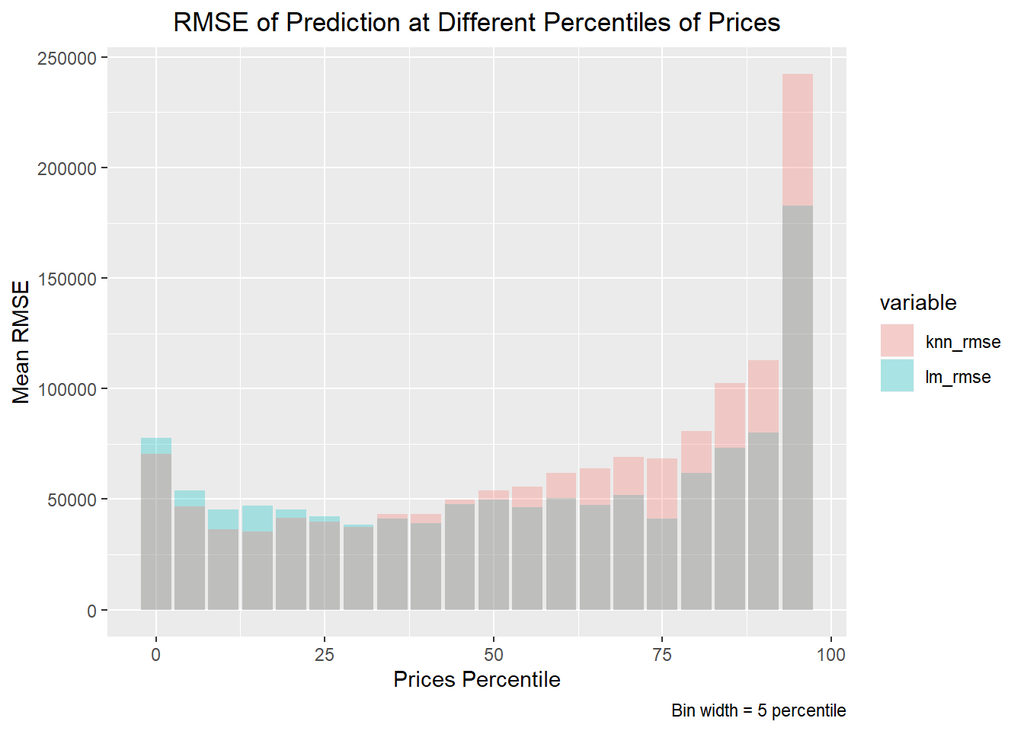

### Conclusion

We can see that Linear regression model performs better for predicting prices of houses in Saratoga. The linear model is easily interpretable and we can see which variables affect prices more.

KNN model is a non parametric model and is known as a slow learning model where it has to train on the data everytime to make a prediction for new values. It cannot learn from the training data and cannot develop a generalize model and that is why it is more susceptible to noise in data and we saw that its errors increase for outliers. Furthermore, we cannot easily see which variables are contributing more towards price changes. With more dimensions or variables the performance of the KNN model deteriorates as compared to Linear model where adding more variables might improve prediction.

Given the results, we can clearly say that Linear Regression model is a better model than KNN in this case. It has low error on average and also at extreme values.

### **Question 2: A Hospital Audit**

#### Part 1: Are some radiologists more clinically conservative than others in recalling patients, holding patient risk factors equal?

Here, we model recall decisions on all risk factors and the radiologist that made the decision to gauge how conservative the doctors are relative to each other.

```r
brca = read.csv("brca.csv")
model_recall = glm(recall ~ . - cancer, data=brca, family=binomial)
summary(model_recall)
```

```
##
## Call:
## glm(formula = recall ~ . - cancer, family = binomial, data = brca)
##
## Deviance Residuals:
##     Min       1Q   Median       3Q      Max
## -1.0445  -0.6185  -0.5186  -0.3761   2.7939
##
## Coefficients:
##                          Estimate Std. Error z value Pr(>|z|)
## (Intercept)              -3.27515    0.64028  -5.115 3.13e-07 ***
## radiologistradiologist34 -0.52171    0.32764  -1.592  0.11132
## radiologistradiologist66  0.35466    0.27895   1.271  0.20358
## radiologistradiologist89  0.46376    0.28026   1.655  0.09797 .
## radiologistradiologist95 -0.05219    0.29380  -0.178  0.85900
## ageage5059                0.11121    0.29534   0.377  0.70651
## ageage6069                0.15683    0.36212   0.433  0.66494
## ageage70plus              0.10782    0.36923   0.292  0.77028
## history                   0.21588    0.23301   0.926  0.35419
## symptoms                  0.72928    0.35897   2.032  0.04219 *
## menopausepostmenoNoHT    -0.19342    0.23732  -0.815  0.41506
## menopausepostmenounknown  0.40267    0.46399   0.868  0.38548
## menopausepremeno          0.34208    0.31269   1.094  0.27396
## densitydensity2           1.22015    0.53897   2.264  0.02358 *
## densitydensity3           1.41907    0.53562   2.649  0.00806 **
## densitydensity4           1.00034    0.60196   1.662  0.09656 .
## ---
## Signif. codes:  0 '***' 0.001 '**' 0.01 '*' 0.05 '.' 0.1 ' ' 1
##
## (Dispersion parameter for binomial family taken to be 1)
##
##     Null deviance: 834.25  on 986  degrees of freedom
## Residual deviance: 799.99  on 971  degrees of freedom
## AIC: 831.99
##
## Number of Fisher Scoring iterations: 5
```

In this output, we can see the estimates on the different radiologists, which tells us how conservative they are. Notice, our output only has four radiologists shown but there are actually 5 radiologists of interest. The fifth one(radiologist 13) is excluded and represented within the intercept. Then, the radiologist estimates in this output are just used to compare against that fifth radiologist. For example, radiologist 34 has an estimate of -.52, which corresponds to multiplying the radioligist 13 odds of recall by .6, holding all other risk factors equal, therefore this radiologist is less conservative than the baseline radiologist(the fifth radiolist not shown in the output) at the hospital.

Analagously, radiologist 89 seems to be the most conservative with an estimate of .46 which cooresponds to multiplying the odds of recall by 1.58(again, comparing to the fifth radiologist not shown in the output), holding other risk factors constant.

In conclusion, yes, some radioligists seem to be more conservative than others. This model would suggest that if the same patient saw both radiologist 34 and radiologist 89, radiologist 89 would be about 2.6 times more likely to recall them. This is a pretty concerning figure. We would like our cross-doctor reliability to be higher. It seems logical that there should be some stable risk of cancer that should determine recall and which doctor you have shouldn’t influence the decision, at least not to the magnitude we see here. Moreover, here is our radiologist conservativeness ranking

1. Radiologist 89
2. Radiologist 66
3. Radiologist 13
4. Radiologist 95
5. Radiologist 34

#### Part 2: When the radiologists at this hospital interpret a mammogram to make a decision on whether to recall the patient, does the data suggest that they should be weighing some clinical risk factors more heavily than they currently are?

```r
model_cancer = glm(cancer ~ ., data=brca, family=binomial)
summary(model_cancer)
```

```
##
## Call:
## glm(formula = cancer ~ ., family = binomial, data = brca)
##
## Deviance Residuals:
##     Min       1Q   Median       3Q      Max
## -1.1394  -0.2468  -0.1670  -0.1380   3.2213
##
## Coefficients:
##                           Estimate Std. Error z value Pr(>|z|)
## (Intercept)              -5.475184   1.308560  -4.184 2.86e-05 ***
## radiologistradiologist34  0.019054   0.564041   0.034   0.9731
## radiologistradiologist66 -0.369522   0.541216  -0.683   0.4948
## radiologistradiologist89 -0.233148   0.569854  -0.409   0.6824
## radiologistradiologist95 -0.384849   0.578076  -0.666   0.5056
## recall                    2.335523   0.368592   6.336 2.35e-10 ***
## ageage5059                0.477893   0.639295   0.748   0.4547
## ageage6069                0.398328   0.812756   0.490   0.6241
## ageage70plus              1.436443   0.736670   1.950   0.0512 .
## history                   0.247484   0.438785   0.564   0.5727
## symptoms                 -0.008199   0.715848  -0.011   0.9909
## menopausepostmenoNoHT    -0.173097   0.455574  -0.380   0.7040
## menopausepostmenounknown  0.819953   0.728254   1.126   0.2602
## menopausepremeno          0.230478   0.661825   0.348   0.7277
## densitydensity2           0.718016   1.079528   0.665   0.5060
## densitydensity3           0.834956   1.081480   0.772   0.4401
## densitydensity4           1.998087   1.133849   1.762   0.0780 .
## ---
## Signif. codes:  0 '***' 0.001 '**' 0.01 '*' 0.05 '.' 0.1 ' ' 1
##
## (Dispersion parameter for binomial family taken to be 1)
##
##     Null deviance: 315.59  on 986  degrees of freedom
## Residual deviance: 260.27  on 970  degrees of freedom
## AIC: 294.27
##
## Number of Fisher Scoring iterations: 7
```

There are some pretty large estimates on some of the risk factors! For example, tissue density type 4 had an estimate of 1.998 which cooresponds to being 7.37x more likely to have cancer than patients with density 1, holding all else fixed.

Family history of cancer, tissue density, and age all seem to have some extra information that could be utilized in the recall decision. Patients with tissue density 4 are 7.4x more likely to get cancer, holding recall decision fixed. Patients with family history of cancer are 1.28x more likely to get cancer than patients without history of breast cancer, holding recall decision fixed. This “incorrect” weighting of risk factors also shows up in the raw error rates below. This can be seen below in the increase in false positives and false negatives when moving from history=0 to history=1. 1.5% of the patients who weren’t recalled ended up having cancer when they didn’t have any family history of breast cancer. When they did have family history of breast cancer, this figure jumps to 2.75%. 84.8% of the patients who were recalled didn’t end up having cancer in the case where they had no family history of breast cancer. In the case where they did have family history of breast cancer, this figure jumps to 86.2%. This reinforces the fact that we could get better recall performance from weighting tissue density 4 and family history of breast cancer more heavily in our decision to perform addition diagnostic tests or not. There are other factors with similar results but I just went over two of them.

```r
xtabs(~cancer + recall + history, brca) %>% prop.table(margin=c(2, 3))
```

```
## , , history = 0
##
##       recall
## cancer          0          1
##      0 0.98414986 0.84873950
##      1 0.01585014 0.15126050
##
## , , history = 1
##
##       recall
## cancer          0          1
##      0 0.97241379 0.86206897
##      1 0.02758621 0.13793103
```

```r
xtabs(~cancer + recall + density, brca) %>% prop.table(margin=c(2, 3))
```

```
## , , density = density1
##
##       recall
## cancer          0          1
##      0 1.00000000 0.75000000
##      1 0.00000000 0.25000000
##
## , , density = density2
##
##       recall
## cancer          0          1
##      0 0.98591549 0.85416667
##      1 0.01408451 0.14583333
##
## , , density = density3
##
##       recall
## cancer          0          1
##      0 0.98153034 0.87654321
##      1 0.01846966 0.12345679
##
## , , density = density4
##
##       recall
## cancer          0          1
##      0 0.95604396 0.73333333
##      1 0.04395604 0.26666667
```

In conclusion, the doctors could adjust how they are currently weighting different risk factors to make more accurate evidence-based decisions about recall and reduce unneccessary diagnostic tests as well as make sure people who need diagnostic tests are getting them. Ultimately, this should also lead to better outcomes for the patients because we will catch the cancer sooner for the patients who have breast cancer.